# Dead wood stocks and fluxes for Barro Colorado Island 50-ha forest dynamic plot, 2017-2024

Lily F. Pitcher and Helene C. Muller-Landau

2025-07-23

### Study site and sample design

Further details of sampling design and protocols can be found here:

https://forestgeo.si.edu/protocols/woody-debris

### Contributions and Acknowledgments

Lily Pitcher conducted data cleaning, performed the analyses and wrote this Rmarkdown report. Helene C. Muller-Landau co-designed the study, supervised the field work, supervised the analyses, and edited the report. Pablo Ramos and Paulino Villareal collected the field data. Markku Larjavaara co-designed the study. This work builds on previous data cleaning and analyses by Evan Gora (see in Gora et al. 2019). This study was funded by Smithsonian ForestGEO and the HSBC Climate Partnership.

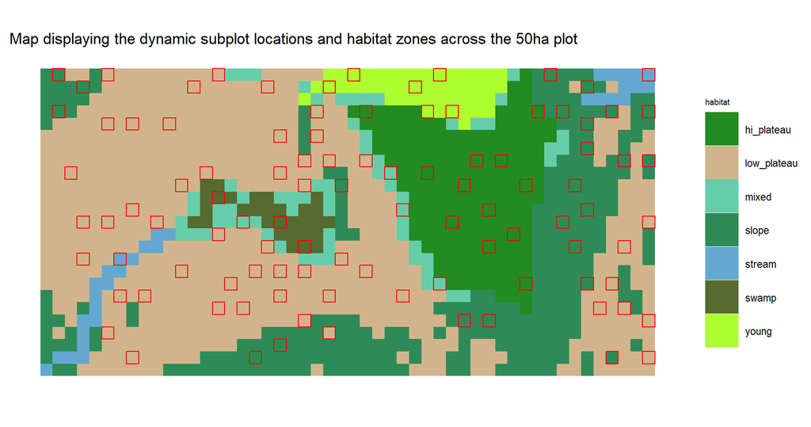

This map shows the 100 dynamic subplots across the 50ha plot, represented by the red squares. Colours represent the different habitat zones across the 50 ha plot.

**Table1**

Summary of census effort for each year including census period (start and end date), total number of pieces of wood measured each year for Fallen and Standing (Total Pieces) and the number of new pieces of dead wood (New pieces). Initials represent the following people involved in the sample collection: R:Pablo Ramos, V:Paulino Villarreal and E is both working as a team.

| Summary of Annual CWD census Year | Summary of Annual CWD census Start Date | Summary of Annual CWD census End Date | Summary of Annual CWD census Total Fallen Pieces | Summary of Annual CWD census New Fallen Pieces | Summary of Annual CWD census Total Standing Pieces | Summary of Annual CWD census New Standing Pieces | Summary of Annual CWD census Field Team |
| --- | --- | --- | --- | --- | --- | --- | --- |
| 2017 | 23 January | 02 March | 257 | 0 | 142 | 0 | R |
| 2018 | 24 January | 15 March | 248 | 59 | 136 | 40 | R |
| 2019 | 17 January | 28 February | 272 | 60 | 131 | 31 | E, R |
| 2020 | 03 February | 06 March | 247 | 46 | 130 | 42 | R, V |
| 2021 | 22 February | 10 March | 234 | 49 | 140 | 45 | E, R, V |
| 2022 | 07 February | 22 February | 235 | 45 | 133 | 41 | E, V |
| 2023 | 08 February | 13 March | 227 | 46 | 128 | 26 | E, R, V |
| 2024 | 02 February | 14 March | 233 | 41 | 102 | 20 | E, V |

### Calculations of CWD stocks and fluxes

This report calculates annual stocks and fluxes of standing and fallen coarse woody debris. The data were formatted and cleaned prior to loading into this report using the code **clean0_bci50deadwood_rawtoformatted.RMD** and **clean1_bci50deadwood_formattedtocorrected.Rmd**. Calculations for individual sample pieces are conducted in **density_calculation_bci50deadwood_correctedtoprocessed.Rmd**. Explanations of all calculations and further information can be found in **CalculationExplanation_for_deadwoodStocks&Fluxes.pdf**.

### Total estimates for CWD stocks, fluxes and residence time for the BCI 50-ha plot

**Table 2**

Estimated mean stocks and fluxes of fallen and standing CWD calculated by first averaging over the one hundred 40 x 40 m dynamics plots, then averaging over years (2017-2024). Estimated total stocks of deadwood (Mean Total), and estimated annual deadwood input (Mean Input) for both volume and mass per ha. Residence time represents the average residence time of dead wood in the plot which is calculated as mean stocks divided by the mean inputs.

| Coarse Woody Debris Summary Statistics Mean Total Mass (Mg ha<sup>-1</sup>) | Coarse Woody Debris Summary Statistics Mean Input Mass (Mg ha<sup>-1</sup>y<sup>-1</sup>) | Coarse Woody Debris Summary Statistics Mean Total Volume (m<sup>3</sup> ha<sup>-1</sup>) | Coarse Woody Debris Summary Statistics Mean Input Volume (m<sup>3</sup> ha<sup>-1</sup> y<sup>-1</sup>) | Coarse Woody Debris Summary Statistics Residence time (y<sup>-1</sup>) |
| --- | --- | --- | --- | --- |
| **Fallen** |  |  |  |  |
| 9.95 | 2.31 | 37.44 | 8.41 | 4.31 |
| **Standing** |  |  |  |  |
| 6.82 | 2.33 | 13.85 | 5.44 | 2.93 |

### Annual variation in woody debris stocks and fluxes

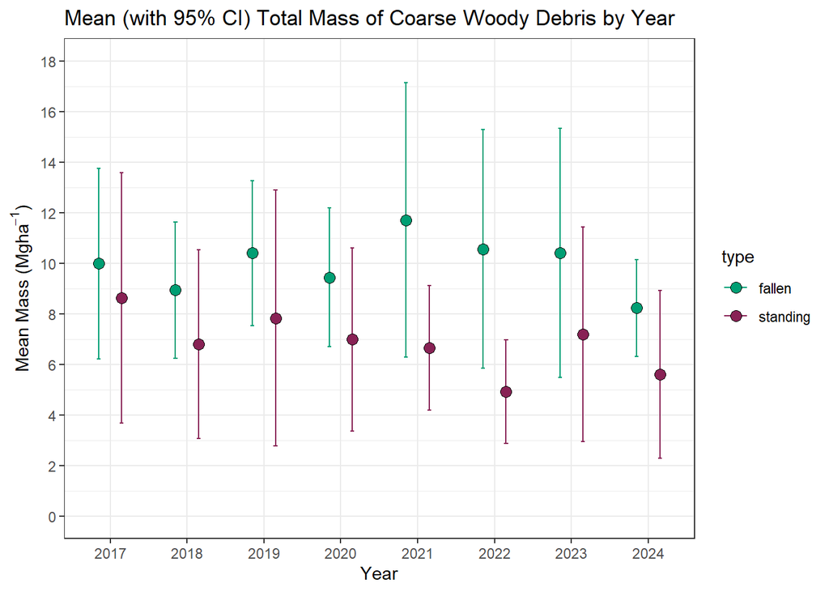

**Figure 1**

Annual variation in mean total mass of fallen and standing coarse woody debris (CWD) per hectare, with 95% confidence intervals (CIs calculated as 1.96 times the standard error of the mean over the one hundred 40 x 40 m subplots).

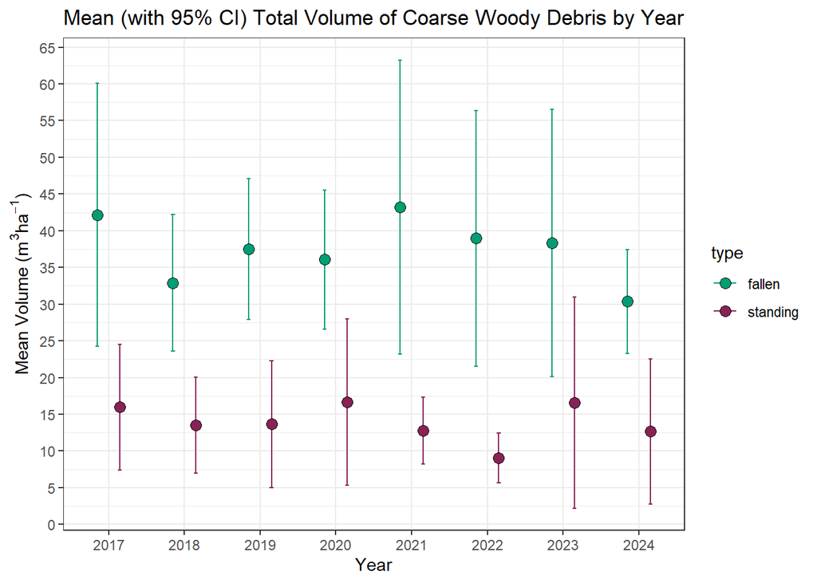

**Figure 2**

Annual variation in mean total volume of fallen and standing CWD per hectare, with 95% confidence intervals (CIs calculated as 1.96 times the standard error of the mean over the one hundred 40 x 40 m subplots).

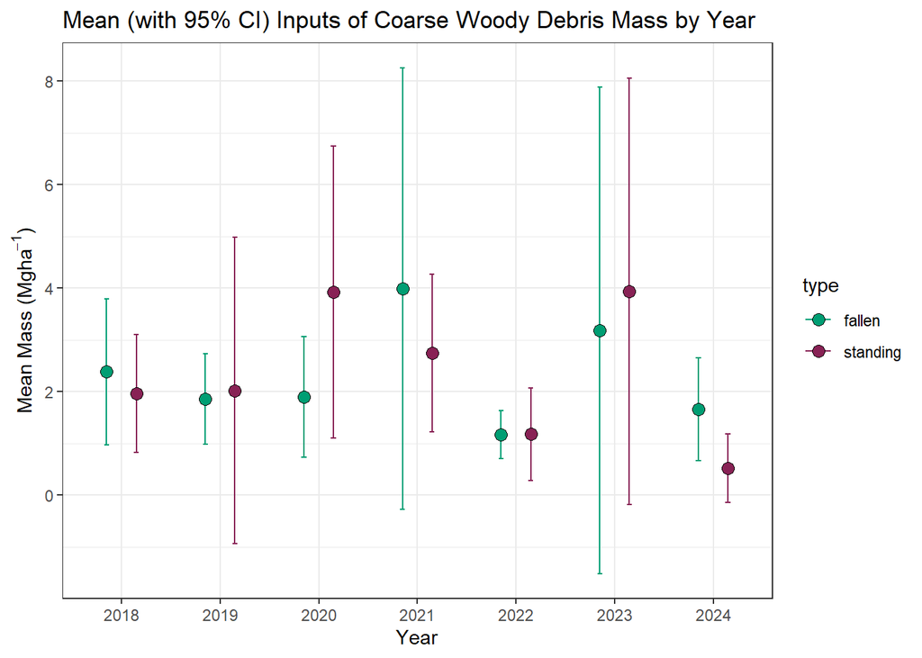

**Figure 3**

Annual variation in mean input mass of fallen and standing CWD per hectare, with 95% confidence intervals (CIs calculated as 1.96 times the standard error of the mean over the one hundred 40 x 40 m subplots).

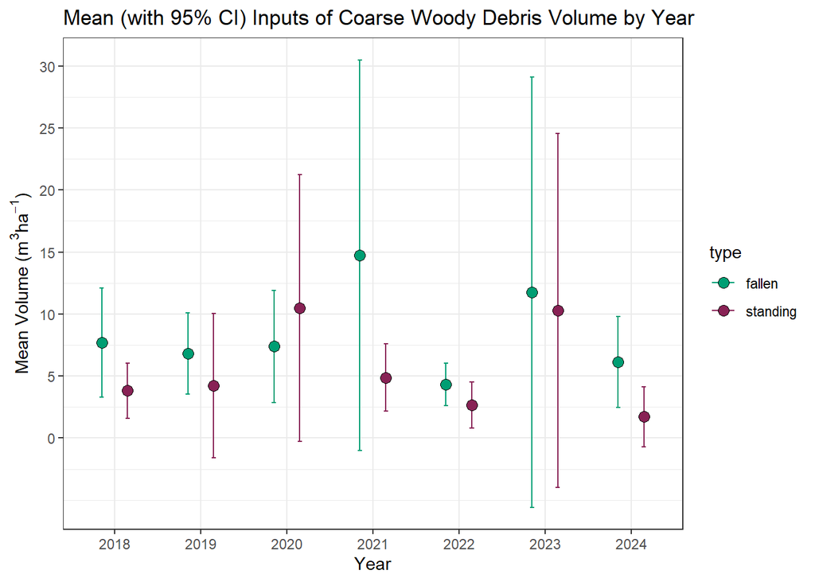

**Figure 4**

Annual variation in mean input volume of fallen and standing CWD per hectare, with 95% confidence intervals (CIs calculated as 1.96 times the standard error of the mean over the one hundred 40 x 40 m subplots).

### Distribution of CWD stocks and fluxes across the dynamic subplots

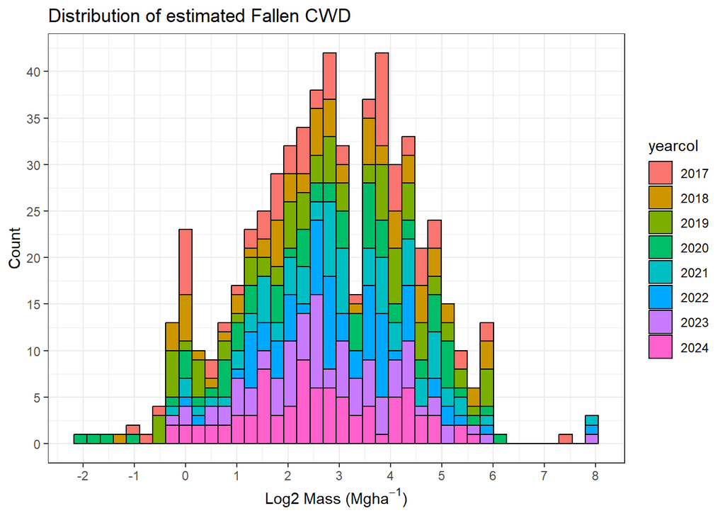

**Figure 5**

Distribution of log₂-transformed total estimated mass of fallen coarse woody debris (CWD) per subplot, coloured by year. The x-axis represents log₂-transformed mass (Mg ha⁻¹), and the y-axis shows the count of subplots within each bin.

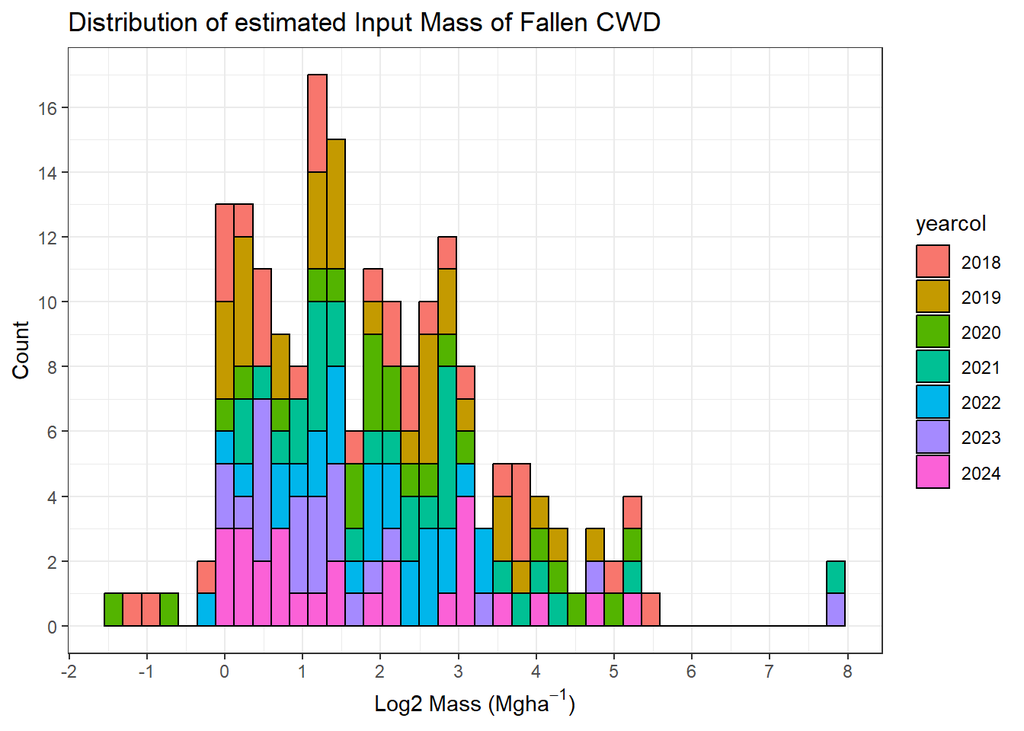

**Figure 6**

Distribution of log₂-transformed input mass of fallen CWD per subplot (excluding 2017), coloured by year. The x-axis represents log₂-transformed mass (Mg ha⁻¹), and the y-axis shows the count of subplots within each bin.

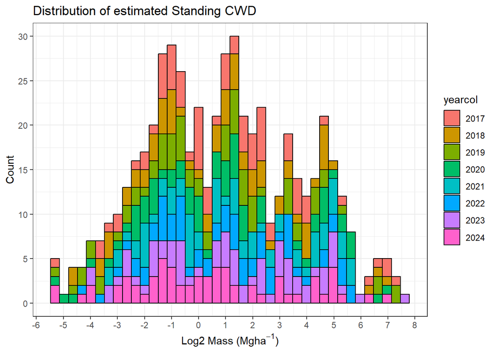

**Figure 7**

Distribution of log₂-transformed total estimated mass of standing coarse woody debris (CWD) per subplot, coloured by year. The x-axis represents log₂-transformed mass (Mg ha⁻¹), and the y-axis shows the count of subplots within each bin.

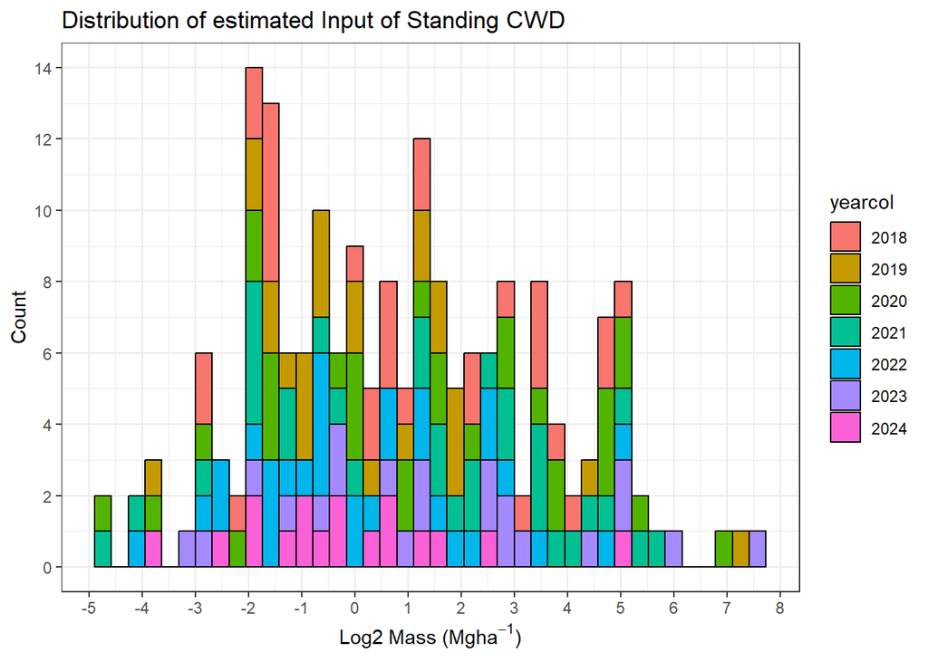

**Figure 8**

Distribution of log₂-transformed input mass of standing CWD per subplot (excluding 2017), coloured by year. The x-axis represents log₂-transformed mass (Mg ha⁻¹), and the y-axis shows the count of subplots within each bin.

### Variation in CWD stocks and fluxes over time within subplots

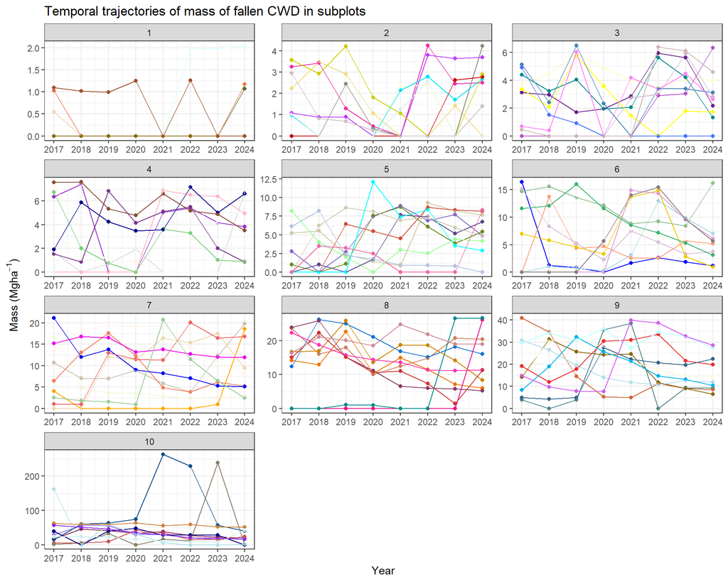

**Figure 9** Interannual variation in estimated fallen CWD mass for each 40 × 40 m subplot, with subplots grouped by quantiles (specifically, deciles) of maximum total mass (for readability). Lines represent individual subplot trajectories over time. Note that the y axes differ for different groups of subplots.

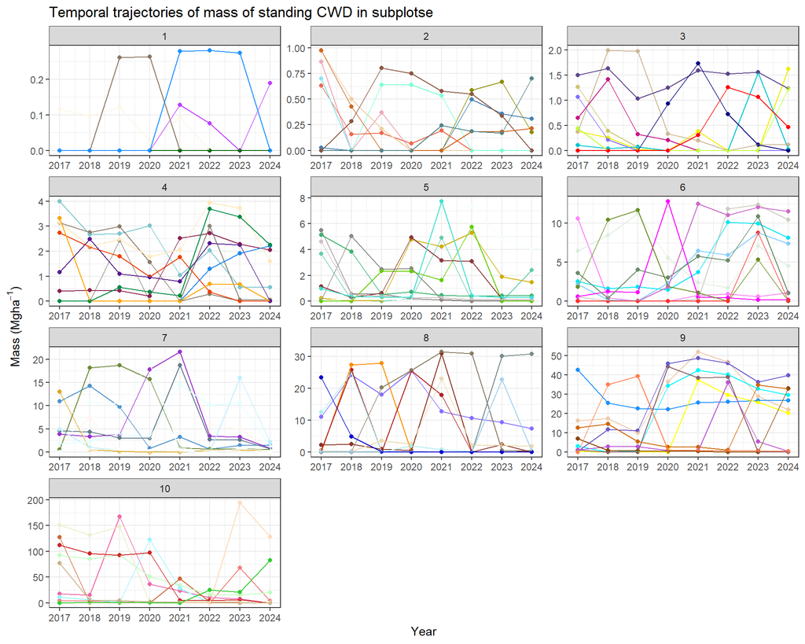

**Figure 10**

Interannual variation in estimated standing CWD mass for each 40 × 40 m subplot, with subplots grouped by quantiles (specifically, deciles) of maximum total mass (for readability). Lines represent individual subplot trajectories over time. Note that the y axes differ for different groups of subplots.

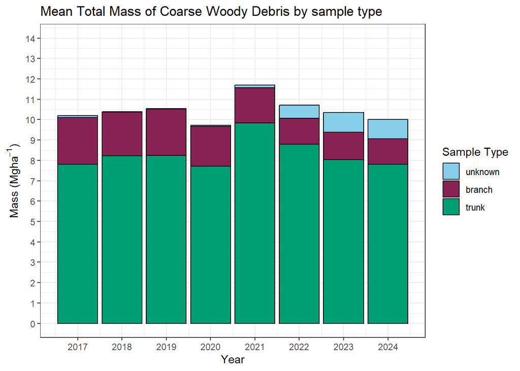

**Figure 11**

Mean total mass of fallen CWD (Mg ha⁻¹) per year, grouped by sample type (branch, trunk, unknown). Bars represent the stacked mean mass of each component, illustrating changes in the composition of fallen woody debris through time.